# week_07_review_boxplots

## CMPINF 2100 Week 07

### Review: Boxpots

Although we will review boxplots, we will discuss limitations as well!

## Import Modules

```python
import numpy as np
import pandas as pd
import matplotlib.pyplot as plt

import seaborn as sns
```

## Read data

```python
gap_df = pd.read_csv("gapminder.tsv", sep="\t")
```

```python
gap_df.info()
```

```
<class 'pandas.core.frame.DataFrame'>
RangeIndex: 1704 entries, 0 to 1703
Data columns (total 6 columns):
 #   Column     Non-Null Count  Dtype
---  ------     --------------  -----
 0   country    1704 non-null   object
 1   continent  1704 non-null   object
 2   year       1704 non-null   int64
 3   lifeExp    1704 non-null   float64
 4   pop        1704 non-null   int64
 5   gdpPercap  1704 non-null   float64
dtypes: float64(2), int64(2), object(2)
memory usage: 80.0+ KB
```

## Boxplot

The boxplot is a tool for exploring the relationships between CATEGORICAL and CONTINUOUS variables.

In Seaborn, it is part of the sns.catplot() FIGURE LEVEL function.

The x variable is associated with the categorical variable and the y variable is associated with the continuous variable.

The BOXPLOT summarizes the CONDITIONAL DISTRIBUTION with SEVERAL summary statistics.

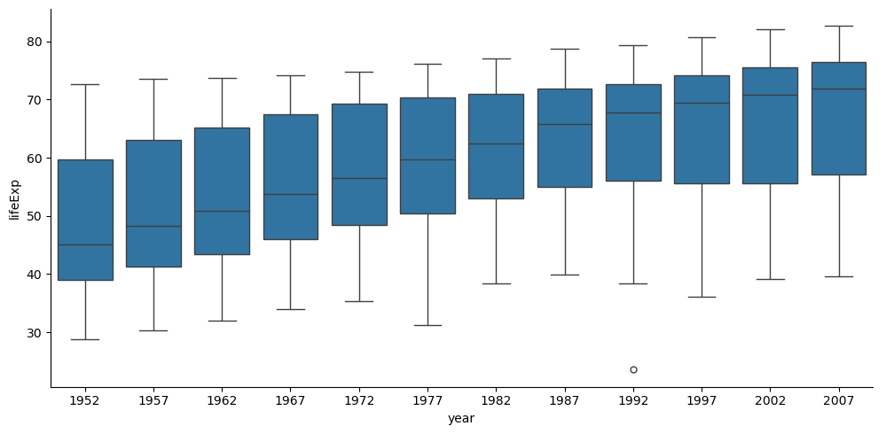

```python
sns.catplot(data=gap_df, x="year", y="lifeExp", kind="box", aspect=2)

plt.show()
```

Lets look at the relationship between continent and lifeExp.

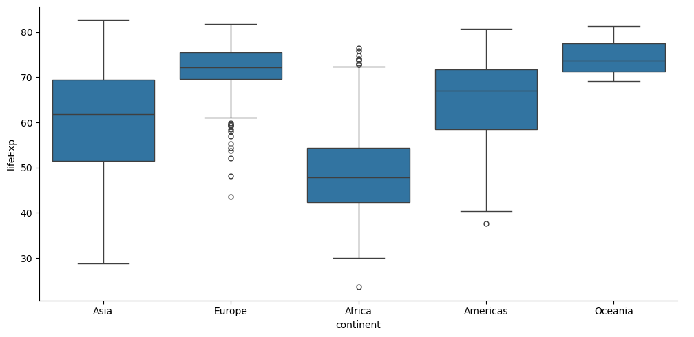

```python
sns.catplot(data=gap_df, x="continent", y="lifeExp", kind="box", aspect=2)

plt.show()
```

In Summary, Bixplots allow us to answer several IMPORTANT questions.

- Does the MEDIAN appear to change across categories?
- Does the VARIATION appear to change across the categories?
- More generally, are the summary statistics different across the categories?

## What is the boxplot best suited for?

The boxplot is at its best when the CONDITIONAL DISTRIBUTION are roughly SYMMETRIC.

We must check the SHAPE of the conditional distributions!!

One way to do that is with the FACETED histograms!!

Lets return to the CONDITIONAL DISTRIBUTION of lifeExp GIVEN year.

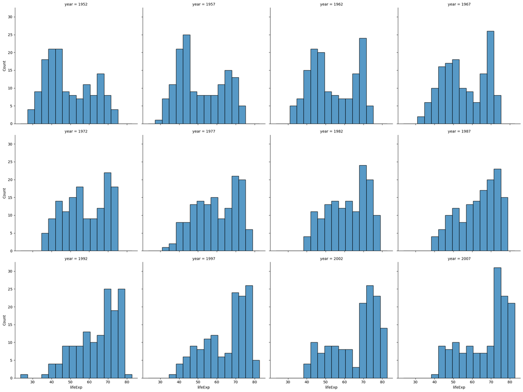

```python
sns.displot(data=gap_df, x="lifeExp", col="year", kind="hist", col_wrap=4)

plt.show()
```

None of the facets show EXTREME lack of symmetry!!

Lack of symmetry is referred to as a SKEW.

What does EXTREME SKEW look like? And what are the consequences of EXTREME skew??

Load in a dataset that has EXTREME SKEW!!

```python
diamonds = sns.load_dataset("diamonds")
```

```python
diamonds.info()
```

```
<class 'pandas.core.frame.DataFrame'>
RangeIndex: 53940 entries, 0 to 53939
Data columns (total 10 columns):
 #   Column   Non-Null Count  Dtype
---  ------   --------------  -----
 0   carat    53940 non-null  float64
 1   cut      53940 non-null  category
 2   color    53940 non-null  category
 3   clarity  53940 non-null  category
 4   depth    53940 non-null  float64
 5   table    53940 non-null  float64
 6   price    53940 non-null  int64
 7   x        53940 non-null  float64
 8   y        53940 non-null  float64
 9   z        53940 non-null  float64
dtypes: category(3), float64(6), int64(1)
memory usage: 3.0 MB
```

```python
diamonds.dtypes
```

```
carat       float64
cut        category
color      category
clarity    category
depth       float64
table       float64
price         int64
x           float64
y           float64
z           float64
dtype: object
```

```python
diamonds.count()
```

```
carat      53940
cut        53940
color      53940
clarity    53940
depth      53940
table      53940
price      53940
x          53940
y          53940
z          53940
dtype: int64
```

```python
diamonds.isna().sum()
```

```
carat      0
cut        0
color      0
clarity    0
depth      0
table      0
price      0
x          0
y          0
z          0
dtype: int64
```

```python
diamonds.dtypes.value_counts()
```

```
float64     6
category    1
category    1
category    1
int64       1
Name: count, dtype: int64
```

The cat data type is a SPECIAL data type for CATEGORICAL vars within Pandas.

```python
diamonds.color.value_counts(normalize=True)
```

```
color
G    0.209344
E    0.181628
F    0.176900
H    0.153949
D    0.125603
I    0.100519
J    0.052058
Name: proportion, dtype: float64
```

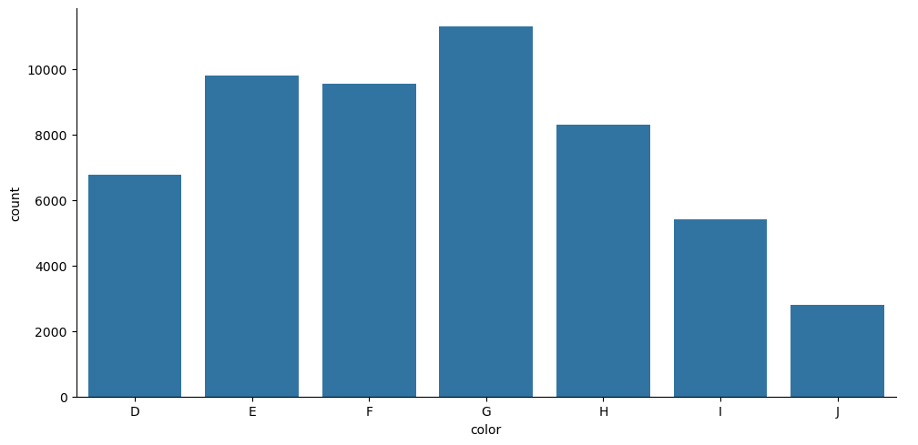

```python
sns.catplot(data=diamonds, x="color", kind="count", aspect=2)

plt.show()
```

Lets now examine the MARGINAL DISTRIBUTION of the continuous variable price.

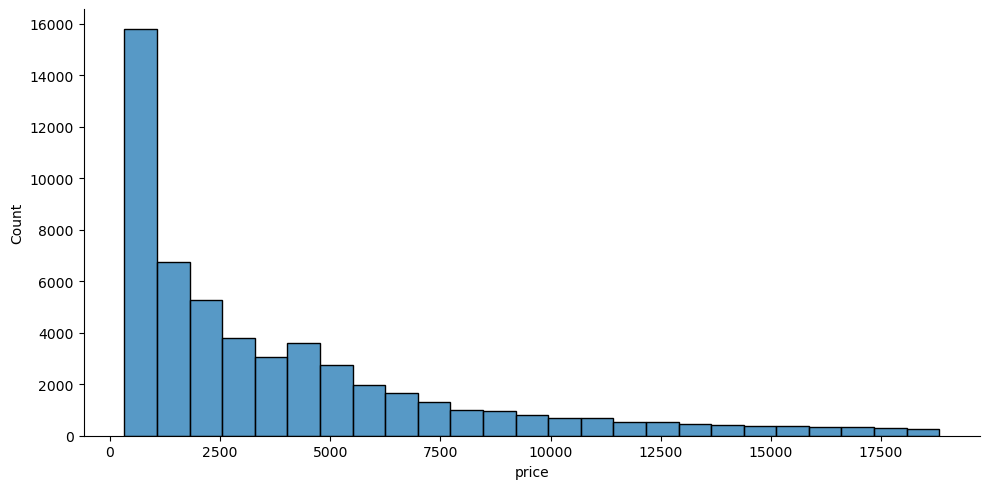

```python
sns.displot(data=diamonds, x="price", kind="hist", bins=25, aspect=2)

plt.show()
```

Lets include the KDE on top of the histogram to get a SMOOTHER picture of the distribution.

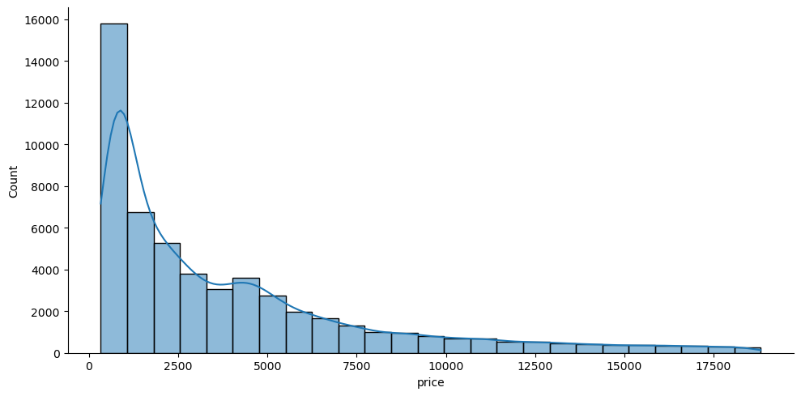

```python
sns.displot(data=diamonds, x="price", kind="hist", bins=25, aspect=2, kde=True)

plt.show()
```

Lets now examine the CONDITIONAL DISTRIBUTION of price GIVEN color.

We will visualize the categories via facets.

By default, ALL FACETS SHARE the x and y-axis bounds!!

Sometimes we need to MODIFY the bounds to allow them to be NOT SHARED or FREE!!

Lets change the y-axis bounds to be FREE in the conditional distribution figure.

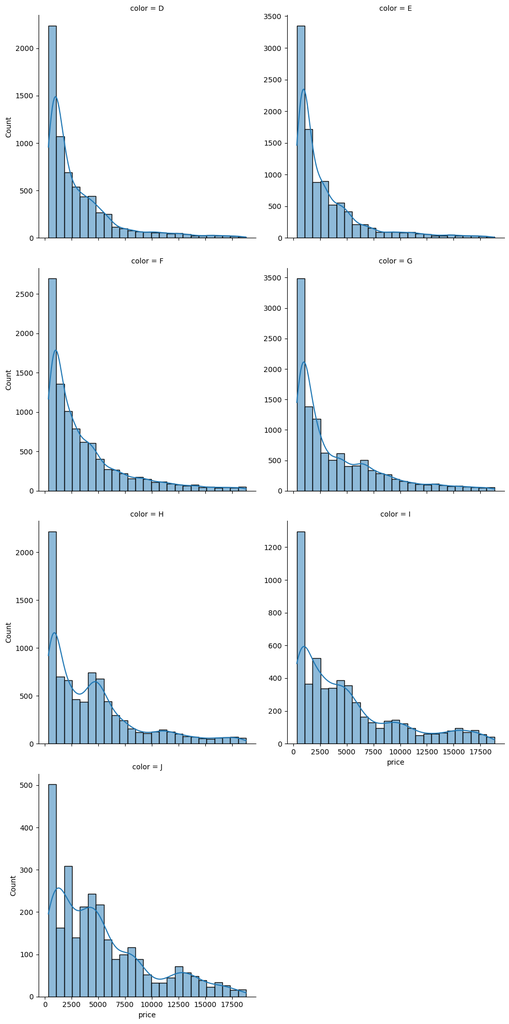

```python
sns.displot(data=diamonds, x="price", col="color", kind="hist", bins=25, kde=True,
           facet_kws={"sharey":False}, col_wrap=2)

plt.show()
```

What is the consequence of the SKEW or LONG TAIL behavior on the BOXPLOT??

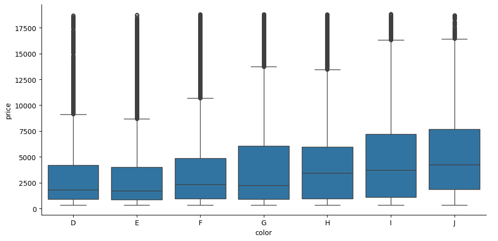

```python
sns.catplot(data=diamonds, x="color", y="price", kind="box", aspect=2)

plt.show()
```

But are the most frequent intervals contained in the BOXES???

EXTREMELY SKEWED distributions will have the MOST FREQUENT INTERVALS near the LOWER or UPPER bounds!!

The boxplot CANNOT represent theat behavior because BOXPLOTS cannot show the distsribution shape!!

We can see the shape with FACETED HISTOGRAMS but a draw back of FACETS is we have to look at many subplots!!

What if we used CONDITIONAL KDE plots with the cat var associated with the hue argument???

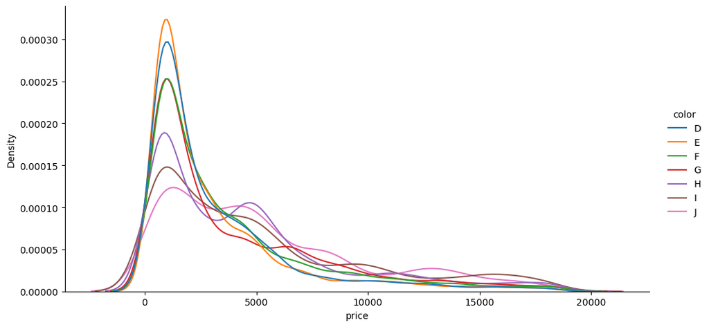

```python
sns.displot(data=diamonds, x="price", hue="color", kind="kde", common_norm=False, aspect=2)

plt.show()
```

CONDITIONAL KDE PLOTS can be very busy to look at when we have more than 4 categories!!

## Violin Plots

Shows CONDITIONAL KDE plots side by side within a single axis rather than across multiple subplots!!

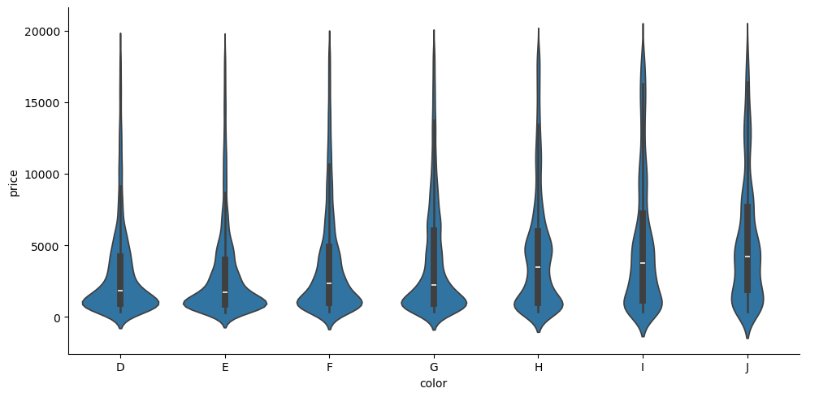

```python
sns.catplot(data=diamonds, x="color", y="price", kind="violin", aspect=2)

plt.show()
```

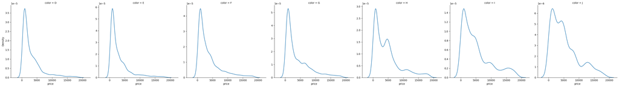

```python
sns.displot(data=diamonds, x="price", col="color", kind="kde",
           facet_kws={"sharey": False})

plt.show()
```

We can show HORIZONTAL lines for the QUANTILES

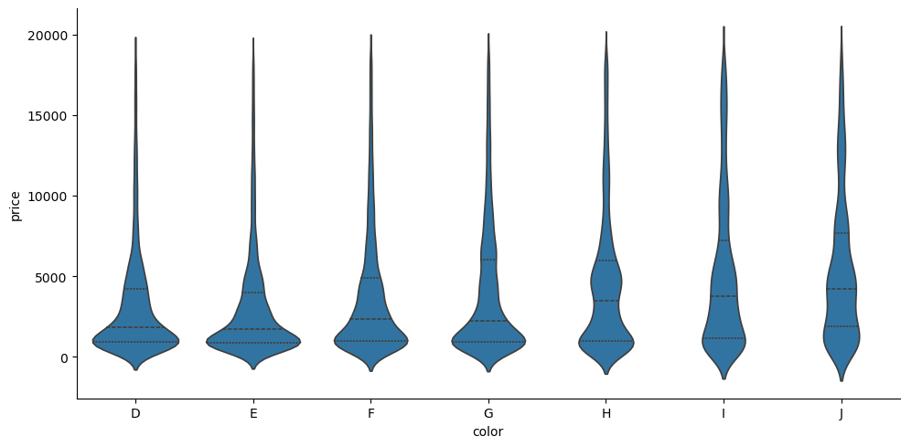

```python
sns.catplot(data=diamonds, x="color", y="price", kind="violin", aspect=2,
           inner="quartile")

plt.show()
```

In Summary:

- Always look at boxplots to study how the summary statistics CHANGE across categories.
- But..you must ALSO look at if the distributional SHAPE is SYMMETRIC and if the distributional shape CHANGES across categories!
  - Use faceted histograms/kds plots
  - Use violin plots

Go back to the GAP MINDER data set.

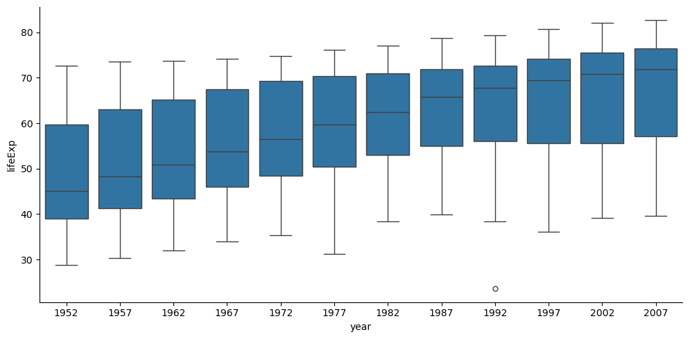

```python
sns.catplot(data=gap_df, x="year", y="lifeExp", kind="box", aspect=2)

plt.show()
```

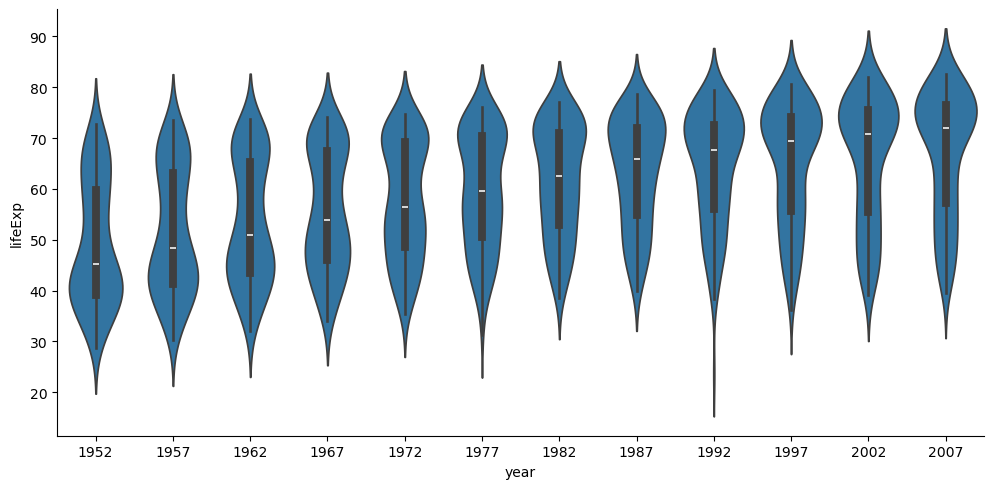

```python
sns.catplot(data=gap_df, x="year", y="lifeExp", kind="violin", aspect=2)

plt.show()
```